# Relationship between storms and other severe weather events and the economic and public health problems of communities in the United States

Carlos Hernández

17/9/2020

```r
# libraries
library(ggplot2)
library(dplyr)
library(ggpubr)

Sys.setlocale("LC_ALL","English") # set English as locale if necessary
```

```
## [1] "LC_COLLATE=English_United States.1252;LC_CTYPE=English_United States.1252;LC_MONETARY=English_United States.1252;LC_NUMERIC=C;LC_TIME=English_United States.1252"
```

```r
options(scipen=999)  # turn-off scientific notation like 1e+48
```

## Sypnosis

Storms and other severe weather events can cause economic and public health problems for communities and municipalities. Many severe events can result in fatalities, injuries, and property damage, and preventing such outcomes as much as possible is a key concern.

That is why we believe that it’s of great importance to know which of these events are that cause the greatest economic and health damage in the communities.

So in this data analysis we will focus on answering the following two questions:

1. Across the United States, which types of events (as indicated in the EVTYPE variable) are most harmful with respect to population health?
2. Across the United States, which types of events have the greatest economic consequences?

To answer these questions we will explore the US National Oceanic and Atmospheric Administration (NOAA) storm database. This database tracks the characteristics of major storms and weather events in the United States, including when and where they occur, as well as estimates of deaths, injuries, and property damage.

## Data Processing

The data come in the form of a comma-separated-value file compressed via the bzip2 algorithm to reduce its size. You can download the file here:

- [Storm Data](https://d396qusza40orc.cloudfront.net/repdata%2Fdata%2FStormData.csv.bz2) [47Mb]

There is also some documentation of the database available. Here you will find how some of the variables are constructed/defined.

- National Weather Service [Storm Data Documentation](https://d396qusza40orc.cloudfront.net/repdata%2Fpeer2_doc%2Fpd01016005curr.pdf)
- National Climatic Data Center Storm Events [FAQ](https://d396qusza40orc.cloudfront.net/repdata%2Fpeer2_doc%2FNCDC%20Storm%20Events-FAQ%20Page.pdf)

The events in the database start in the year 1950 and end in November 2011. In the earlier years of the database there are generally fewer events recorded, most likely due to a lack of good records. More recent years should be considered more complete.

In the follow lines of code we download the data automatically into a folder called ‘dataset’ with the name of *FstormData.csv.bz2*.

```r
# create 'dataset' folder if not exists
if(!dir.exists("./dataset")){
    dir.create("./dataset")
}
#download the file into 'dataset' folder if not exists
if(!file.exists("./dataset/FStormData.csv.bz2")){
  download.file(url = "https://d396qusza40orc.cloudfront.net/repdata%2Fdata%2FStormData.csv.bz2"
                ,destfile = "./dataset/FStormData.csv.bz2")
}
```

Now we can load the data into a variable.

```r
# read the csv file (this can take a few seconds)
storm.data <- read.csv("./dataset/FStormData.csv.bz2")
```

Fact this, now we can look at a summary of the data.

```r
str(storm.data)
```

```
## 'data.frame':    902297 obs. of  37 variables:
##  $ STATE__   : num  1 1 1 1 1 1 1 1 1 1 ...
##  $ BGN_DATE  : chr  "4/18/1950 0:00:00" "4/18/1950 0:00:00" "2/20/1951 0:00:00" "6/8/1951 0:00:00" ...
##  $ BGN_TIME  : chr  "0130" "0145" "1600" "0900" ...
##  $ TIME_ZONE : chr  "CST" "CST" "CST" "CST" ...
##  $ COUNTY    : num  97 3 57 89 43 77 9 123 125 57 ...
##  $ COUNTYNAME: chr  "MOBILE" "BALDWIN" "FAYETTE" "MADISON" ...
##  $ STATE     : chr  "AL" "AL" "AL" "AL" ...
##  $ EVTYPE    : chr  "TORNADO" "TORNADO" "TORNADO" "TORNADO" ...
##  $ BGN_RANGE : num  0 0 0 0 0 0 0 0 0 0 ...
##  $ BGN_AZI   : chr  "" "" "" "" ...
##  $ BGN_LOCATI: chr  "" "" "" "" ...
##  $ END_DATE  : chr  "" "" "" "" ...
##  $ END_TIME  : chr  "" "" "" "" ...
##  $ COUNTY_END: num  0 0 0 0 0 0 0 0 0 0 ...
```

[output cut: 23 more lines]

We can see that the data contains 902297 rows and 37 variables and are very well formatted, here I have an unique consideration, and is that PROPDMG and CROPDMG variables are expressed in units of type K (Thousands), M (Millions) and B (Billions) , as we can see in PROPDMGEXP and CROPDMGEXP variables. I think that the best choice is convert this values to its real value (ex. 1K = 1000).

Well, we can get this very quickly by writing a simple function to do it for us.

```r
as.usd.dollar <- function(value, exp){
  if(exp == "K"){
    return(value*1000)
  }else if(exp=="M"){
    return(value*1000000)
  }else if(exp =="B"){
    return(value*1000000000)
  }else{
    return(value)
  }
}

damage <- select(storm.data, EVTYPE, PROPDMG, PROPDMGEXP, CROPDMG, CROPDMGEXP, FATALITIES, INJURIES)
damage <- mutate(damage, PROPDMG.USD = as.usd.dollar(PROPDMG, PROPDMGEXP))
damage <- mutate(damage, CROPDMG.USD = as.usd.dollar(CROPDMG, CROPDMGEXP))

# remove unused variables for a data set more clean
damage <- select(damage, EVTYPE, PROPDMG.USD, CROPDMG.USD, FATALITIES, INJURIES)
```

```r
str(damage)
```

```
## 'data.frame':    902297 obs. of  5 variables:
##  $ EVTYPE     : chr  "TORNADO" "TORNADO" "TORNADO" "TORNADO" ...
##  $ PROPDMG.USD: num  25000 2500 25000 2500 2500 2500 2500 2500 25000 25000 ...
##  $ CROPDMG.USD: num  0 0 0 0 0 0 0 0 0 0 ...
##  $ FATALITIES : num  0 0 0 0 0 0 0 0 1 0 ...
##  $ INJURIES   : num  15 0 2 2 2 6 1 0 14 0 ...
```

Additionally we can need create some new data groups.

For fatalities:

```r
fatalities <- damage %>% group_by(EVTYPE) %>% summarise(Count = sum(FATALITIES))
fatalities <- fatalities[fatalities$Count > 150,]
```

For injuries:

```r
injuries <- damage %>% group_by(EVTYPE) %>% summarise(Count = sum(INJURIES))
injuries <- injuries[injuries$Count > 1000,]
```

For property damage:

```r
prop <- damage %>% group_by(EVTYPE) %>% summarise(Count = sum(PROPDMG.USD))
prop <- prop[prop$Count > 20000000,]
```

And finally for Crop damage:

```r
crop <- damage %>% group_by(EVTYPE) %>% summarise(Count = sum(CROPDMG.USD))
crop <- crop[crop$Count > 5000,]
```

## Results

### Across the United States, which types of events are most harmful with respect to population health?

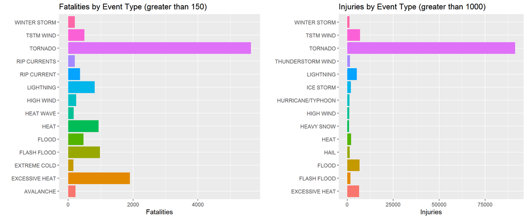

```r
fatalities.plot <- ggplot(fatalities) +
  geom_col(aes(x=fatalities$EVTYPE, y=fatalities$Count, fill = EVTYPE)) +
  xlab("") +
  ylab("Fatalities") +
  ggtitle("Fatalities by Event Type (greater than 150)") +
  coord_flip() +
  theme(legend.position = "none")

injuries.plot <- ggplot(injuries) +
  geom_col(aes(x=injuries$EVTYPE, y=injuries$Count, fill = EVTYPE)) +
  xlab("") +
  ylab("Injuries") +
  ggtitle("Injuries by Event Type (greater than 1000)") +
  coord_flip() +
  theme(legend.position = "none")

ggarrange(fatalities.plot, injuries.plot, ncol = 2, nrow = 1)
```

In the previous graphs, we have a very clear vision of the types of events that most harm the health of the population.

### Across the United States, which types of events have the greatest economic consequences?

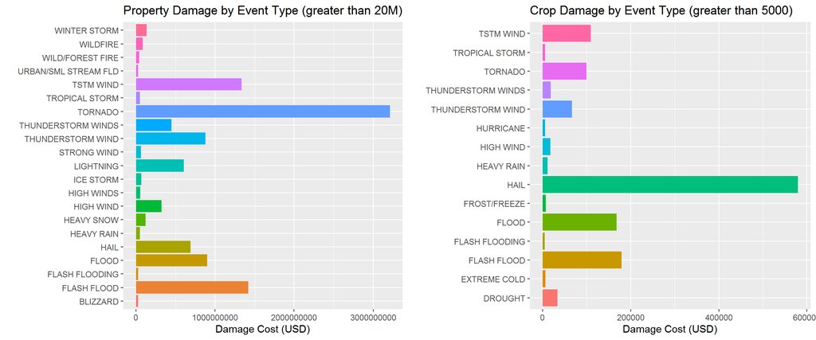

```r
prop.plot <- ggplot(prop) +
  geom_col(aes(x=prop$EVTYPE, y=prop$Count, fill = EVTYPE)) +
  xlab("") +
  ggtitle("Property Damage by Event Type (greater than 20M)") +
  ylab("Damage Cost (USD)") +
  coord_flip() +
  theme(legend.position = "none")

crop.plot <- ggplot(crop) +
  geom_col(aes(x=crop$EVTYPE, y=crop$Count, fill = EVTYPE)) +
  xlab("") +
  ggtitle("Crop Damage by Event Type (greater than 5000)") +
  ylab("Damage Cost (USD)") +
  coord_flip() +
  theme(legend.position = "none")


  ggarrange(prop.plot, crop.plot, ncol = 2, nrow = 1)
```